# 과제6 2차

Student

2024-06-02

# Sentiment Analysis on Twitter Dataset

“Tweets.csv” 파일은 트위터에서 미국의 6개 항공사(American, Delta, SouthWest, United, US Airways, Virgin America)를 언급하는 tweet 14,640개에 대한 정보를 수집한 데이터셋으로, 본 과제에서는 다음 두 변수를 활용한다.

- airline_sentiment: “positive”, “negative”, “neutral”
- text: tweet 텍스트 변수 airline_sentiment는 각 tweet 텍스트가 항공사에 대한 긍정적인 내용인지, 부정적인 내용인지, 중립적인 내용인지에 따라 positive, negative, neutral로 분류한 결과를 나타낸다. 본 과제에서는 tweet 텍스트로부터 positive/negative/neutral 여부를 판별하기 위한 모델을 만들어본다.

## 1. 데이터 분석 및 시각화

```r
# 필요한 패키지 로드
library(ggplot2)
library(dplyr)
library(tm)
library(SnowballC)
library(wordcloud)
library(e1071)
library(nnet)
library(rsample)
library(glmnet)
library(caret)
library(rpart)
library(rpart.plot)
library(randomForest)
# 데이터 읽기
tweets <- read.csv("Tweets.csv", stringsAsFactors = FALSE)

# 데이터 구조 확인
str(tweets)
```

```
## 'data.frame':    14640 obs. of  15 variables:
##  $ tweet_id                    : num  5.7e+17 5.7e+17 5.7e+17 5.7e+17 5.7e+17 ...
##  $ airline_sentiment           : chr  "neutral" "positive" "neutral" "negative" ...
##  $ airline_sentiment_confidence: num  1 0.349 0.684 1 1 ...
##  $ negativereason              : chr  "" "" "" "Bad Flight" ...
##  $ negativereason_confidence   : num  NA 0 NA 0.703 1 ...
##  $ airline                     : chr  "Virgin America" "Virgin America" "Virgin America" "Virgin America" ...
##  $ airline_sentiment_gold      : chr  "" "" "" "" ...
##  $ name                        : chr  "cairdin" "jnardino" "yvonnalynn" "jnardino" ...
##  $ negativereason_gold         : chr  "" "" "" "" ...
##  $ retweet_count               : int  0 0 0 0 0 0 0 0 0 0 ...
##  $ text                        : chr  "@VirginAmerica What @dhepburn said." "@VirginAmerica plus you've added commercials to the experience... tacky." "@VirginAmerica I didn't today... Must mean I need to take another trip!" "@VirginAmerica it's really aggressive to blast obnoxious \"entertainmen…
##  $ tweet_coord                 : chr  "" "" "" "" ...
##  $ tweet_created               : chr  "2015-02-24 11:35:52 -0800" "2015-02-24 11:15:59 -0800" "2015-02-24 11:15:48 -0800" "2015-02-24 11:15:36 -0800" ...
##  $ tweet_location              : chr  "" "" "Lets Play" "" ...
##  $ user_timezone               : chr  "Eastern Time (US & Canada)" "Pacific Time (US & Canada)" "Central Time (US & Canada)" "Pacific Time (US & Canada)" ...
```

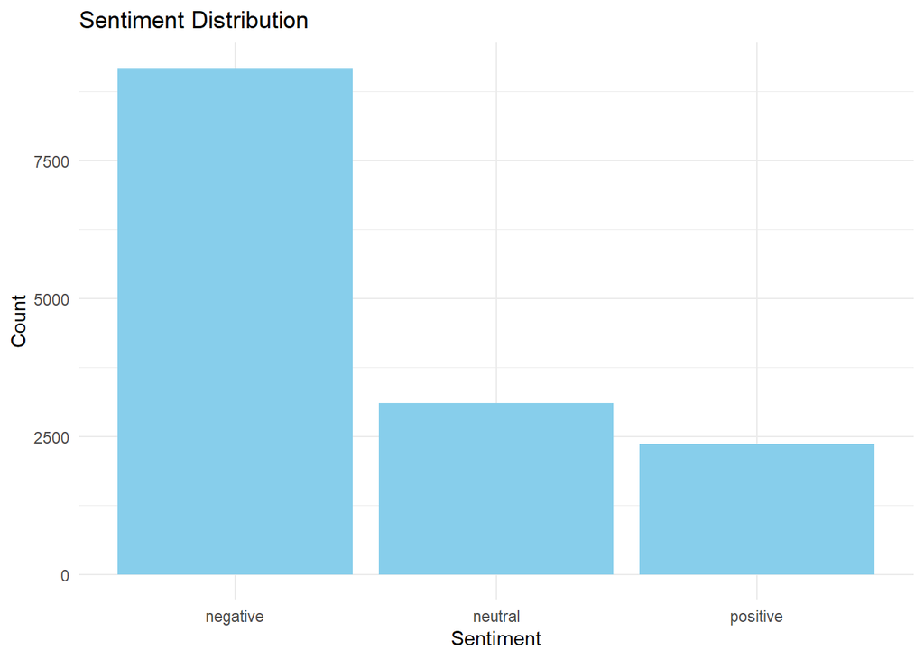

```r
# 데이터 불러오기

# sentiment 분포 시각화
ggplot(tweets, aes(x = airline_sentiment)) +
  geom_bar(fill = "skyblue") +
  theme_minimal() +
  labs(title = "Sentiment Distribution", x = "Sentiment", y = "Count")
```

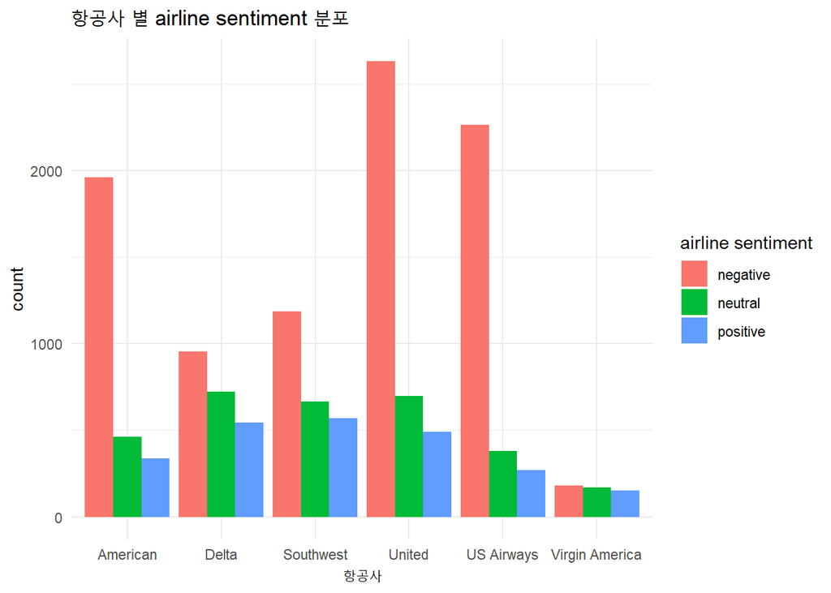

```r
# 시각화
ggplot(tweets, aes(x=airline, fill=airline_sentiment)) +
  geom_bar(position="dodge") +
  theme_bw() +
  labs(title="항공사 별 airline sentiment 분포", x="항공사", y="count", fill="airline sentiment") +
  theme_minimal()
```

[결과]

전반적으로 모든 항공사가 negative 내용이 많다. 또한, negative, neutral, positive 순으로 내용이 많은 것도 일치한다.

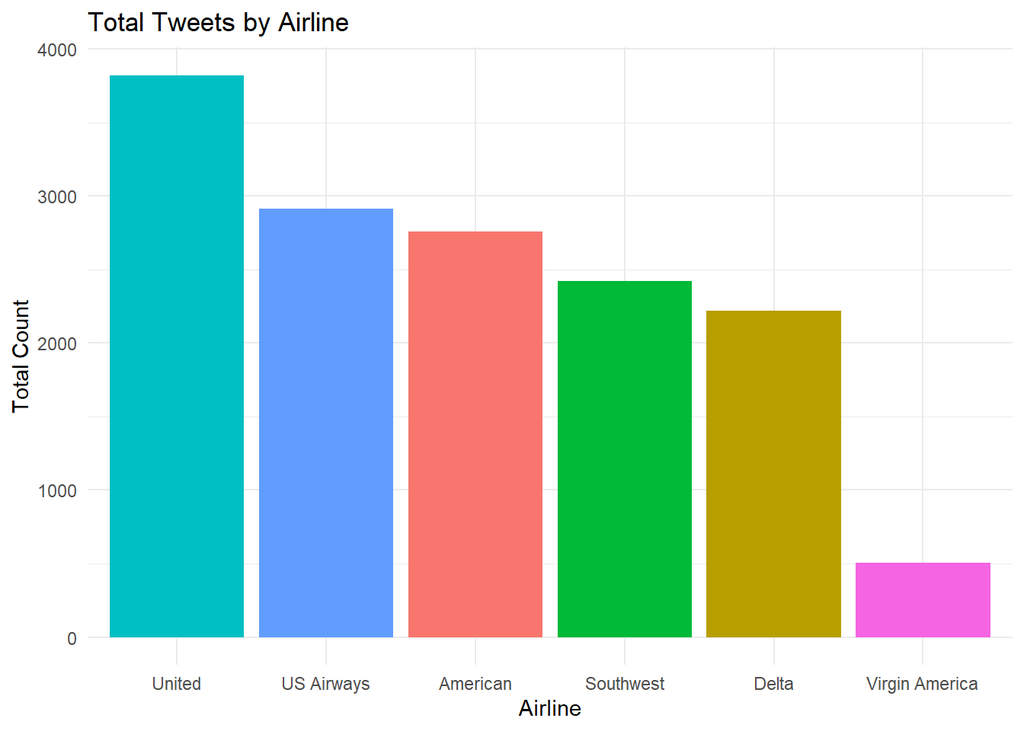

```r
# 항공사별 총 트윗 수 계산
total_tweets <- tweets %>%
  count(airline) %>%
  rename(total_count = n)

# 항공사별 감정 비율 계산
sentiment_distribution <- tweets %>%
  count(airline, airline_sentiment) %>%
  group_by(airline) %>%
  mutate(percentage = n / sum(n)) %>%
  ungroup()

# 시각화 - 항공사별 총 트윗 수
ggplot(total_tweets, aes(x = reorder(airline, -total_count), y = total_count, fill = airline)) +
  geom_bar(stat = "identity") +
  labs(title = "Total Tweets by Airline",
       x = "Airline",
       y = "Total Count",
       fill = "Airline") +
  theme_minimal() +
  theme(legend.position = "none")
```

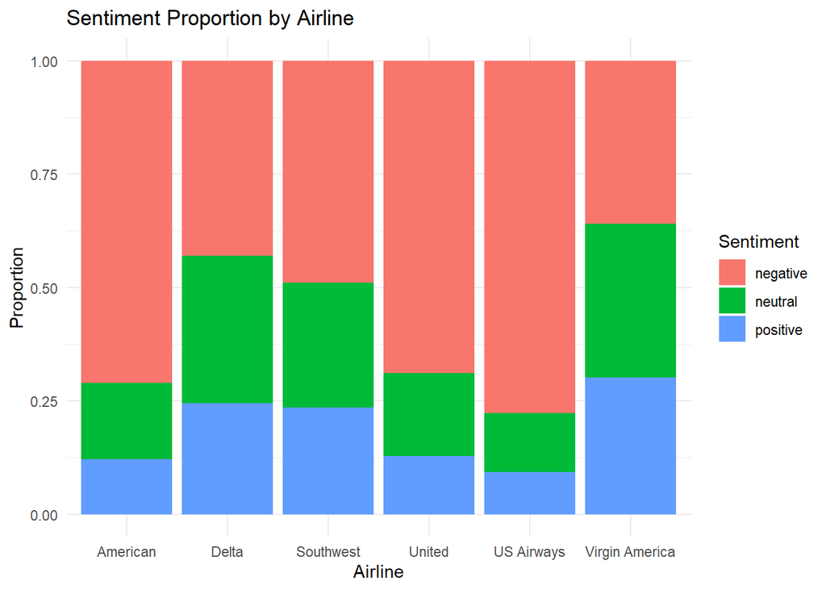

```r
# 시각화 - 항공사별 감정 비율
ggplot(sentiment_distribution, aes(x = airline, y = percentage, fill = airline_sentiment)) +
  geom_bar(stat = "identity", position = "fill") +
  labs(title = "Sentiment Proportion by Airline",
       x = "Airline",
       y = "Proportion",
       fill = "Sentiment") +
  theme_minimal()
```

[결과]

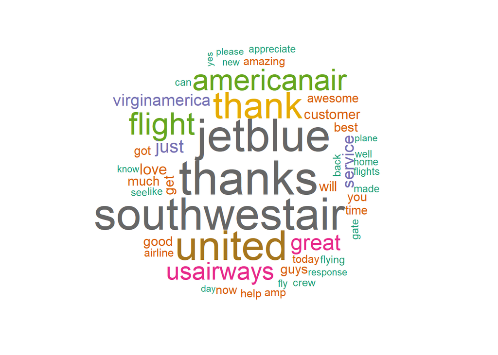

```r
# positive/negative/neutral 분리
positive <- subset(tweets, airline_sentiment == "positive")
negative <- subset(tweets, airline_sentiment == "negative")
neutral <- subset(tweets, airline_sentiment == "neutral")

# 긍정적 감정 워드 클라우드 생성
wordcloud(positive$text, max.words=50, random.order=FALSE, colors=brewer.pal(8, "Dark2"))
```

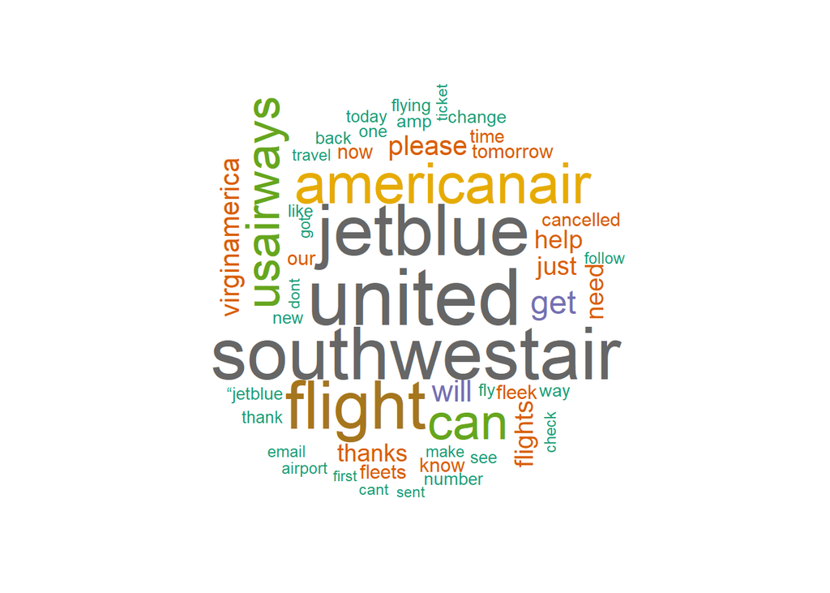

```r
# 중립적 감정 워드 클라우드 생성
wordcloud(neutral$text, max.words=50, random.order=FALSE, colors=brewer.pal(8, "Dark2"))
```

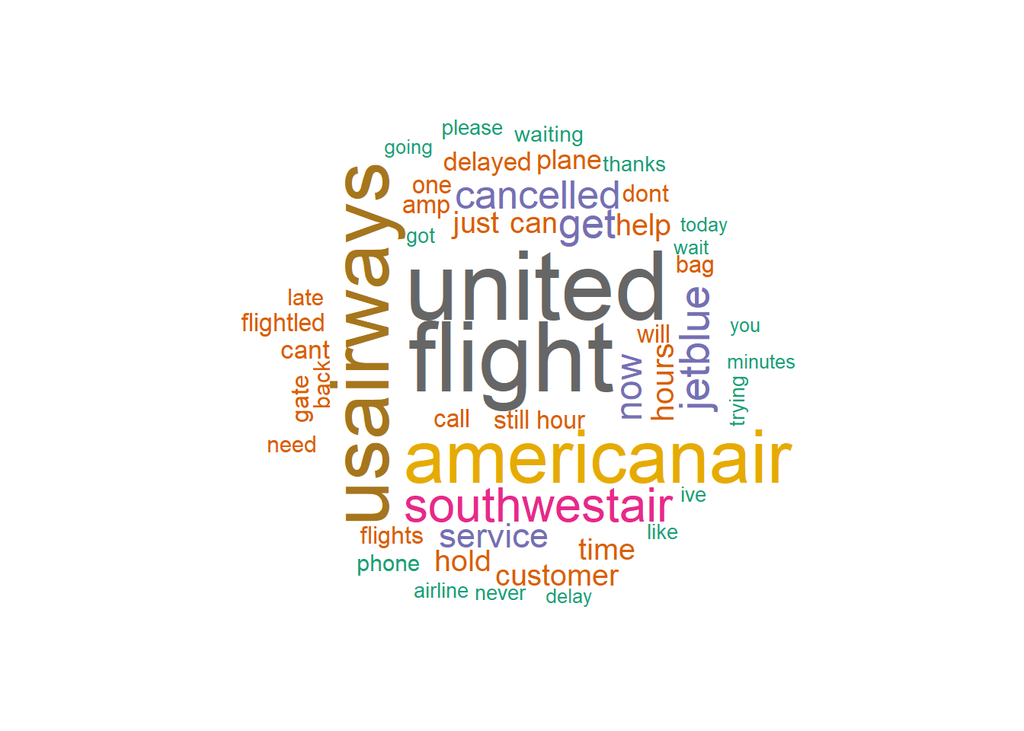

```r
# 부정적 감정 워드 클라우드 생성
wordcloud(negative$text, max.words=50, random.order=FALSE, colors=brewer.pal(8, "Dark2"))
```

[결과]

* positive : thanks, southwestair, jetblue, united, thank 등의 단어들이 많이 보인다.  
* neutral : united, jetblue, southwestair, americanair 등의 단어들이 많이 보인다.  
* negative : united, flight americanair, usairways 등의 단어들이 많이 보인다.

당연하게도 positive는 긍정적인 단어들이, negative는 부정적인 단어들이 다수 포함되어 있다. 또한 전체적으로 항공사의 이름이 많이 언급된다. 특히, jetblue가 비교대상으로 많이 언급되는 것 같다.

## 2. 텍스트 데이터 전처리

```r
# target 변수를 factor로 변환
tweets$airline_sentiment <- factor(tweets$airline_sentiment)

# positive/negative/neutral 분포 확인
table(tweets$airline_sentiment)
```

```
##
## negative  neutral positive
##     9178     3099     2363
```

```r
tweets_corpus <- VCorpus(VectorSource(tweets$text))

# 대소문자 통합
tweets_corpus_clean <- tm_map(tweets_corpus, content_transformer(tolower))
# 숫자 제거
tweets_corpus_clean <- tm_map(tweets_corpus_clean, removeNumbers)
# 불용어(stopwords) 제거
tweets_corpus_clean <- tm_map(tweets_corpus_clean, removeWords, stopwords())
# 문장부호(punctuation) 제거
tweets_corpus_clean <- tm_map(tweets_corpus_clean, removePunctuation)
# 어간 추출(stemming)
tweets_corpus_clean <- tm_map(tweets_corpus_clean, stemDocument)
# 공백 제거
tweets_corpus_clean <- tm_map(tweets_corpus_clean, stripWhitespace)

# Document-Term Matrix (DTM) 생성
tweets_dtm <- DocumentTermMatrix(tweets_corpus_clean)
tweets_dtm
```

```
## <<DocumentTermMatrix (documents: 14640, terms: 11264)>>
## Non-/sparse entries: 136251/164768709
## Sparsity           : 100%
## Maximal term length: 46
## Weighting          : term frequency (tf)
```

```r
tweets_tfidf <- weightTfIdf(tweets_dtm)
tweets_tfidf
```

```
## <<DocumentTermMatrix (documents: 14640, terms: 11264)>>
## Non-/sparse entries: 136251/164768709
## Sparsity           : 100%
## Maximal term length: 46
## Weighting          : term frequency - inverse document frequency (normalized) (tf-idf)
```

```r
# 예시 문장
example_sentence <- tweets_corpus[[100]]$content

# 원본 문장 출력
print(paste("Original sentence:", example_sentence))
```

```
## [1] "Original sentence: @VirginAmerica is anyone doing anything there today?  Website is useless and no one is answering the phone."
```

```r
# 1. 대소문자 통합
lowercase_sentence <- tolower(example_sentence)
print(paste("Lowercase sentence:", lowercase_sentence))
```

```
## [1] "Lowercase sentence: @virginamerica is anyone doing anything there today?  website is useless and no one is answering the phone."
```

```r
# 2. 숫자 제거
no_numbers_sentence <- removeNumbers(lowercase_sentence)
print(paste("No numbers sentence:", no_numbers_sentence))
```

```
## [1] "No numbers sentence: @virginamerica is anyone doing anything there today?  website is useless and no one is answering the phone."
```

```r
# 3. 불용어 제거
no_stopwords_sentence <- removeWords(no_numbers_sentence, stopwords("en"))
print(paste("No stopwords sentence:", no_stopwords_sentence))
```

```
## [1] "No stopwords sentence: @virginamerica  anyone  anything  today?  website  useless   one  answering  phone."
```

```r
# 4. 문장부호 제거
no_punctuation_sentence <- removePunctuation(no_stopwords_sentence)
print(paste("No punctuation sentence:", no_punctuation_sentence))
```

```
## [1] "No punctuation sentence: virginamerica  anyone  anything  today  website  useless   one  answering  phone"
```

```r
# 5. 공백 제거
no_whitespace_sentence <- stripWhitespace(no_punctuation_sentence)
print(paste("No extra whitespace sentence:", no_whitespace_sentence))
```

```
## [1] "No extra whitespace sentence: virginamerica anyone anything today website useless one answering phone"
```

```r
# 6. 어간 추출
stemmed_sentence <- wordStem(unlist(strsplit(no_whitespace_sentence, " ")), language = "en")
stemmed_sentence <- paste(stemmed_sentence, collapse = " ")
print(paste("Stemmed sentence:", stemmed_sentence))
```

```
## [1] "Stemmed sentence: virginamerica anyon anyth today websit useless one answer phone"
```

```r
#단어 수 비교
original_word_count <- length(unlist(strsplit(example_sentence, " ")))
print(paste("Original word count:", original_word_count))
```

```
## [1] "Original word count: 18"
```

```r
final_word_count <- length(unlist(strsplit(stemmed_sentence, " ")))
print(paste("Final word count:", final_word_count))
```

```
## [1] "Final word count: 9"
```

[결과]

전처리가 잘 되는지 확인하기 위해 100번째 text를 살펴본다.

```r
# 100번 이상 발생하는 단어 출력
findFreqTerms(tweets_dtm, lowfreq = 100)
```

```
##   [1] "“jetblu"      "abl"           "actual"        "agent"
##   [5] "ago"           "air"           "airlin"        "airport"
##   [9] "alreadi"       "also"          "alway"         "amaz"
##  [13] "americanair"   "amp"           "anoth"         "answer"
##  [17] "anyon"         "anyth"         "app"           "appreci"
##  [21] "arriv"         "ask"           "attend"        "avail"
##  [25] "awesom"        "back"          "bad"           "bag"
##  [29] "baggag"        "best"          "better"        "board"
##  [33] "book"          "busi"          "call"          "can"
##  [37] "cancel"        "care"          "chang"         "charg"
##  [41] "check"         "claim"         "class"         "come"
##  [45] "confirm"       "connect"       "contact"       "credit"
##  [49] "crew"          "custom"        "day"           "delay"
##  [53] "delta"         "departur"      "dfw"           "differ"
##  [57] "direct"        "disappoint"    "done"          "due"
```

[output cut: 45 more lines]

```r
# 발생 빈도가 매우 적은 단어 제거
tweets_dtm <- removeSparseTerms(tweets_dtm, 0.995)
tweets_tfidf <- removeSparseTerms(tweets_tfidf, 0.995)
print(tweets_dtm)
```

```
## <<DocumentTermMatrix (documents: 14640, terms: 330)>>
## Non-/sparse entries: 90845/4740355
## Sparsity           : 98%
## Maximal term length: 17
## Weighting          : term frequency (tf)
```

```r
print(tweets_tfidf)
```

```
## <<DocumentTermMatrix (documents: 14640, terms: 330)>>
## Non-/sparse entries: 90845/4740355
## Sparsity           : 98%
## Maximal term length: 17
## Weighting          : term frequency - inverse document frequency (normalized) (tf-idf)
```

[결과]

* 대소문자 통합: 모든 텍스트를 소문자로 변환하여 단어의 일관성을 유지했습니다.

* 숫자 제거: 숫자는 의미를 전달하지 않기 때문에 제거했습니다.

* 불용어 제거: ‘the’, ‘is’, ‘in’ 등의 자주 사용되지만 의미가 없는 단어를 제거했습니다.

* 문장부호 제거: 구두점, 마침표 등을 제거하여 단어의 순수한 형태만 남겼습니다.

* 어간 추출: 단어의 어간을 추출하여 기본 형태로 변환했습니다. 예를 들어, ’running’은 ’run’으로 변환되었습니다.

* 공백 제거: 연속된 공백을 단일 공백으로 변환하여 텍스트의 가독성을 높였습니다.

## 3. 데이터 분할 및 모델링

### 3. 데이터 분할

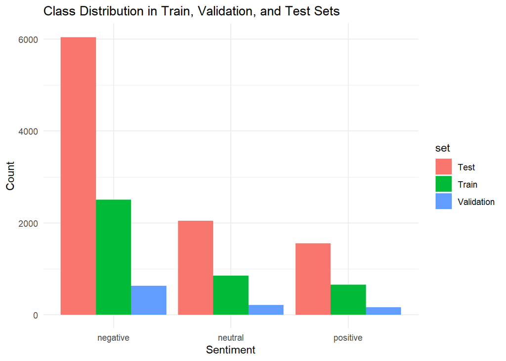

```r
# 데이터 분할
set.seed(123)
train_indices <- 1:5000
train_set <- tweets[train_indices, ]
test_set <- tweets[-train_indices, ]

# Train set을 다시 Train과 Validation set으로 분할

# DTM을 데이터 프레임으로 변환
df_dtm <- as.data.frame(as.matrix(tweets_dtm[1:5000, ]))
df_dtm$airline_sentiment <- train_set$airline_sentiment
set.seed(123)
split_dtm <- initial_split(df_dtm, prop = 0.8, strata = "airline_sentiment")
dtm_train <- training(split_dtm)
dtm_validation <- testing(split_dtm)

# TF-IDF를 데이터 프레임으로 변환
df_tfidf <- as.data.frame(as.matrix(tweets_tfidf[1:5000, ]))
df_tfidf$airline_sentiment <- train_set$airline_sentiment
set.seed(123)
split_tfidf <- initial_split(df_tfidf, prop = 0.8, strata = "airline_sentiment")
tfidf_train <- training(split_tfidf)
tfidf_validation <- testing(split_tfidf)



# 각 데이터 세트의 클래스 분포 시각화
train_dist <- as.data.frame(table(dtm_train$airline_sentiment))
validation_dist <- as.data.frame(table(dtm_validation$airline_sentiment))
test_dist <- as.data.frame(table(test_set$airline_sentiment))

# Test set을 데이터 프레임으로 변환
test_dtm <- as.data.frame(as.matrix(tweets_dtm[-train_indices, ]))
test_dtm$airline_sentiment <- tweets$airline_sentiment[-train_indices]

test_tfidf <- as.data.frame(as.matrix(tweets_tfidf[-train_indices, ]))
test_tfidf$airline_sentiment <- tweets$airline_sentiment[-train_indices]

# 시각화를 위해 데이터 결합
train_dist$set <- 'Train'
validation_dist$set <- 'Validation'
test_dist$set <- 'Test'
dist_data <- rbind(train_dist, validation_dist, test_dist)

# 클래스 분포 시각화
ggplot(dist_data, aes(x = Var1, y = Freq, fill = set)) +
  geom_bar(stat = "identity", position = "dodge") +
  labs(title = "Class Distribution in Train, Validation, and Test Sets",
       x = "Sentiment",
       y = "Count") +
  theme_minimal()
```

## 3.A

지금까지 학습한 모델을 최대한 활용해보고, 분석 과정과 결과를 report하자. 사용하는 모델, 모델에 포함 되는 파라미터에 대한 튜닝, 모델에 포함되는 feature의 수, DTM/TF-IDF 사용 여부 등이 classification accuracy에 영향을 미칠 수 있다.  
[주의: 모델을 수립할 때에는 test set을 사용하여 성능을 비교할 수 없다. 모델 간의 성능 비교를 위해서는 training set 중 일부를 validation set으로 활용하자.]

### Naive Bayes 모델

```r
# Naive Bayes 모델 (DTM)
nb_model_dtm <- naiveBayes(as.matrix(dtm_train[ , -ncol(dtm_train)]), dtm_train$airline_sentiment)
nb_pred_dtm <- predict(nb_model_dtm, as.matrix(dtm_validation[ , -ncol(dtm_validation)]))
nb_pred_dtm <- factor(nb_pred_dtm, levels = levels(dtm_validation$airline_sentiment))

# 성능 평가 (DTM)
nb_cm_dtm <- confusionMatrix(nb_pred_dtm, dtm_validation$airline_sentiment)
print(nb_cm_dtm)
```

```
## Confusion Matrix and Statistics
##
##           Reference
## Prediction negative neutral positive
##   negative      193      17        8
##   neutral        86      51       14
##   positive      347     144      141
##
## Overall Statistics
##
##                Accuracy : 0.3846
##                  95% CI : (0.3544, 0.4156)
##     No Information Rate : 0.6254
##     P-Value [Acc > NIR] : 1
##
##                   Kappa : 0.1559
##
##  Mcnemar's Test P-Value : <2e-16
##
## Statistics by Class:
##
##                      Class: negative Class: neutral Class: positive
## Sensitivity                   0.3083        0.24057          0.8650
## Specificity                   0.9333        0.87326          0.4141
## Pos Pred Value                0.8853        0.33775          0.2231
## Neg Pred Value                0.4470        0.81059          0.9404
## Prevalence                    0.6254        0.21179          0.1628
## Detection Rate                0.1928        0.05095          0.1409
## Detection Prevalence          0.2178        0.15085          0.6314
## Balanced Accuracy             0.6208        0.55691          0.6396
```

```r
# Naive Bayes 모델 (TF-IDF)
nb_model_tfidf <- naiveBayes(as.matrix(tfidf_train[ , -ncol(tfidf_train)]), tfidf_train$airline_sentiment)
nb_pred_tfidf <- predict(nb_model_tfidf, as.matrix(tfidf_validation[ , -ncol(tfidf_validation)]))
nb_pred_tfidf <- factor(nb_pred_tfidf, levels = levels(tfidf_validation$airline_sentiment))

# 성능 평가 (TF-IDF)
nb_cm_tfidf <- confusionMatrix(nb_pred_tfidf, tfidf_validation$airline_sentiment)
print(nb_cm_tfidf)
```

```
## Confusion Matrix and Statistics
##
##           Reference
## Prediction negative neutral positive
##   negative      163      16        9
##   neutral       129      63       20
##   positive      334     133      134
##
## Overall Statistics
##
##                Accuracy : 0.3596
##                  95% CI : (0.3299, 0.3902)
##     No Information Rate : 0.6254
##     P-Value [Acc > NIR] : 1
##
##                   Kappa : 0.1346
##
##  Mcnemar's Test P-Value : <2e-16
##
## Statistics by Class:
##
##                      Class: negative Class: neutral Class: positive
## Sensitivity                   0.2604        0.29717          0.8221
## Specificity                   0.9333        0.81115          0.4427
## Pos Pred Value                0.8670        0.29717          0.2230
## Neg Pred Value                0.4305        0.81115          0.9275
## Prevalence                    0.6254        0.21179          0.1628
## Detection Rate                0.1628        0.06294          0.1339
## Detection Prevalence          0.1878        0.21179          0.6004
## Balanced Accuracy             0.5969        0.55416          0.6324
```

[결과]

정확도가 낮은 이유는 여러 가지가 있을 수 있다. Naive Bayes 모델은 매우 단순한 확률 모델로, 데이터의 구조나 특징에 따라 성능이 크게 달라질 수 있다. 특히, TF-IDF를 사용한 Naive Bayes 모델은 종종 성능이 낮아지는 경향이 있다. 적합한 모델은 아닌듯 하다.

### Logistic Regression 모델

```r
# Logistic Regression 모델 (DTM)
lr_model_dtm <- multinom(airline_sentiment ~ ., data = dtm_train)
lr_pred_dtm <- predict(lr_model_dtm, dtm_validation)

# 성능 평가 (DTM)
lr_cm_dtm <- confusionMatrix(lr_pred_dtm, dtm_validation$airline_sentiment)
print(lr_cm_dtm)
```

```
## Confusion Matrix and Statistics
##
##           Reference
## Prediction negative neutral positive
##   negative      506      95       42
##   neutral        70      93       26
##   positive       50      24       95
##
## Overall Statistics
##
##                Accuracy : 0.6933
##                  95% CI : (0.6637, 0.7218)
##     No Information Rate : 0.6254
##     P-Value [Acc > NIR] : 3.965e-06
##
##                   Kappa : 0.4222
##
##  Mcnemar's Test P-Value : 0.2067
##
## Statistics by Class:
##
##                      Class: negative Class: neutral Class: positive
## Sensitivity                   0.8083        0.43868         0.58282
## Specificity                   0.6347        0.87833         0.91169
## Pos Pred Value                0.7869        0.49206         0.56213
## Neg Pred Value                0.6648        0.85345         0.91827
## Prevalence                    0.6254        0.21179         0.16284
## Detection Rate                0.5055        0.09291         0.09491
## Detection Prevalence          0.6424        0.18881         0.16883
## Balanced Accuracy             0.7215        0.65850         0.74726
```

```r
# Logistic Regression 모델 (TF-IDF)
lr_model_tfidf <- multinom(airline_sentiment ~ ., data = tfidf_train)
lr_pred_tfidf <- predict(lr_model_tfidf, tfidf_validation)

# 성능 평가 (TF-IDF)
lr_cm_tfidf <- confusionMatrix(lr_pred_tfidf, tfidf_validation$airline_sentiment)
print(lr_cm_tfidf)
```

```
## Confusion Matrix and Statistics
##
##           Reference
## Prediction negative neutral positive
##   negative      524      99       44
##   neutral        63      88       29
##   positive       39      25       90
##
## Overall Statistics
##
##                Accuracy : 0.7013
##                  95% CI : (0.6719, 0.7295)
##     No Information Rate : 0.6254
##     P-Value [Acc > NIR] : 2.77e-07
##
##                   Kappa : 0.4257
##
##  Mcnemar's Test P-Value : 0.03515
##
## Statistics by Class:
##
##                      Class: negative Class: neutral Class: positive
## Sensitivity                   0.8371        0.41509         0.55215
## Specificity                   0.6187        0.88340         0.92363
## Pos Pred Value                0.7856        0.48889         0.58442
## Neg Pred Value                0.6946        0.84896         0.91381
## Prevalence                    0.6254        0.21179         0.16284
## Detection Rate                0.5235        0.08791         0.08991
## Detection Prevalence          0.6663        0.17982         0.15385
## Balanced Accuracy             0.7279        0.64925         0.73789
```

[결과]

TF-IDF를 사용한 Logistic Regression 모델이 DTM을 사용한 모델보다 전반적으로 더 높은 accuracy와 Kappa 값을 나타낸다. 특히, Negative 클래스에서의 Balanced Accuracy가 더 높다.

따라서, Logistic Regression 모델 중에서는 TF-IDF를 사용한 모델이 더 나은 성능을 보여주므로 최적의 모델로 선택하는 것이 합리적이다.

### Lasso Regression 모델

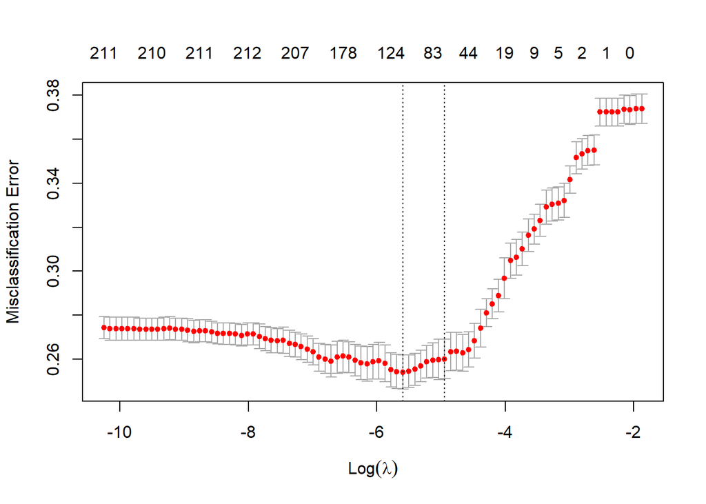

```r
# Logistic Regression 모델 (Lasso Regression) (DTM)
x_train_dtm <- as.matrix(dtm_train[ , -ncol(dtm_train)])
y_train_dtm <- dtm_train$airline_sentiment

x_validation_dtm <- as.matrix(dtm_validation[ , -ncol(dtm_validation)])
y_validation_dtm <- dtm_validation$airline_sentiment

# Cross-Validation을 사용한 Lasso Regression
set.seed(123)
cv_lasso_dtm <- cv.glmnet(x = x_train_dtm, y = y_train_dtm, alpha = 1, family = "multinomial", type.measure = "class", nfolds = 10)
plot(cv_lasso_dtm)
```

```r
lasso_pred_dtm <- predict(cv_lasso_dtm, s = cv_lasso_dtm$lambda.1se, newx = x_validation_dtm, type = "class")

# 성능 평가 (DTM)
lasso_cm_dtm <- confusionMatrix(factor(lasso_pred_dtm, levels = levels(y_validation_dtm)), y_validation_dtm)
print(lasso_cm_dtm)
```

```
## Confusion Matrix and Statistics
##
##           Reference
## Prediction negative neutral positive
##   negative      558     140       55
##   neutral        35      50       15
##   positive       33      22       93
##
## Overall Statistics
##
##                Accuracy : 0.7003
##                  95% CI : (0.6709, 0.7286)
##     No Information Rate : 0.6254
##     P-Value [Acc > NIR] : 3.926e-07
##
##                   Kappa : 0.3812
##
##  Mcnemar's Test P-Value : 4.655e-15
##
## Statistics by Class:
##
##                      Class: negative Class: neutral Class: positive
## Sensitivity                   0.8914        0.23585         0.57055
## Specificity                   0.4800        0.93663         0.93437
## Pos Pred Value                0.7410        0.50000         0.62838
## Neg Pred Value                0.7258        0.82020         0.91794
## Prevalence                    0.6254        0.21179         0.16284
## Detection Rate                0.5574        0.04995         0.09291
## Detection Prevalence          0.7522        0.09990         0.14785
## Balanced Accuracy             0.6857        0.58624         0.75246
```

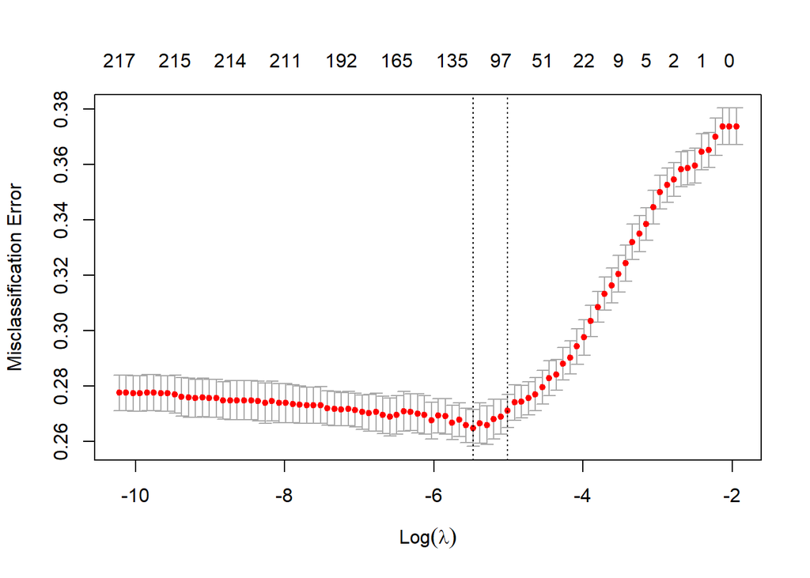

```r
# Logistic Regression 모델 (Lasso Regression) (TF-IDF)
x_train_tfidf <- as.matrix(tfidf_train[ , -ncol(tfidf_train)])
y_train_tfidf <- tfidf_train$airline_sentiment

x_validation_tfidf <- as.matrix(tfidf_validation[ , -ncol(tfidf_validation)])
y_validation_tfidf <- tfidf_validation$airline_sentiment

# Cross-Validation을 사용한 Lasso Regression
set.seed(123)
cv_lasso_tfidf <- cv.glmnet(x = x_train_tfidf, y = y_train_tfidf, alpha = 1, family = "multinomial", type.measure = "class", nfolds = 10)
plot(cv_lasso_tfidf)
```

```r
lasso_pred_tfidf <- predict(cv_lasso_tfidf, s = cv_lasso_tfidf$lambda.1se, newx = x_validation_tfidf, type = "class")

# 성능 평가 (TF-IDF)
lasso_cm_tfidf <- confusionMatrix(factor(lasso_pred_tfidf, levels = levels(y_validation_tfidf)), y_validation_tfidf)
print(lasso_cm_tfidf)
```

```
## Confusion Matrix and Statistics
##
##           Reference
## Prediction negative neutral positive
##   negative      575     131       63
##   neutral        34      61       20
##   positive       17      20       80
##
## Overall Statistics
##
##                Accuracy : 0.7153
##                  95% CI : (0.6862, 0.7431)
##     No Information Rate : 0.6254
##     P-Value [Acc > NIR] : 1.285e-09
##
##                   Kappa : 0.4021
##
##  Mcnemar's Test P-Value : < 2.2e-16
##
## Statistics by Class:
##
##                      Class: negative Class: neutral Class: positive
## Sensitivity                   0.9185        0.28774         0.49080
## Specificity                   0.4827        0.93156         0.95585
## Pos Pred Value                0.7477        0.53043         0.68376
## Neg Pred Value                0.7802        0.82957         0.90611
## Prevalence                    0.6254        0.21179         0.16284
## Detection Rate                0.5744        0.06094         0.07992
## Detection Prevalence          0.7682        0.11489         0.11688
## Balanced Accuracy             0.7006        0.60965         0.72332
```

[결과]

### KNN

```r
# 필요한 패키지 로드
library(class)

# 타겟 변수를 팩터로 변환
dtm_train$airline_sentiment <- as.factor(dtm_train$airline_sentiment)
dtm_validation$airline_sentiment <- as.factor(dtm_validation$airline_sentiment)

# k 값 튜닝
tune_grid_knn <- expand.grid(k = seq(1, 20, by = 1))
train_control <- trainControl(method = "cv", number = 10)

knn_tuned_model_dtm <- train(
  airline_sentiment ~ .,
  data = dtm_train,
  method = "knn",
  tuneGrid = tune_grid_knn,
  trControl = train_control
)

# 최적의 모델 확인
print(knn_tuned_model_dtm)
```

```
## k-Nearest Neighbors
##
## 3999 samples
##  330 predictor
##    3 classes: 'negative', 'neutral', 'positive'
##
## No pre-processing
## Resampling: Cross-Validated (10 fold)
## Summary of sample sizes: 3599, 3600, 3600, 3599, 3599, 3598, ...
## Resampling results across tuning parameters:
##
##   k   Accuracy   Kappa
##    1  0.5868817  0.3019532
##    2  0.5856355  0.2891428
##    3  0.6006418  0.2981655
##    4  0.5998968  0.2852365
##    5  0.6028962  0.2834607
##    6  0.6093968  0.2876871
##    7  0.6148974  0.2896009
##    8  0.6121462  0.2815952
##    9  0.6128980  0.2768158
##   10  0.6138943  0.2759591
##   11  0.6156512  0.2767129
##   12  0.6193987  0.2812906
##   13  0.6196493  0.2797963
##   14  0.6203987  0.2801581
##   15  0.6231493  0.2831476
##   16  0.6226505  0.2817596
##   17  0.6241505  0.2838508
##   18  0.6236493  0.2822522
##   19  0.6246505  0.2835492
##   20  0.6246518  0.2830851
##
## Accuracy was used to select the optimal model using the largest value.
## The final value used for the model was k = 20.
```

```r
best_knn_model_dtm <- knn_tuned_model_dtm$finalModel

# 예측 및 성능 평가
knn_pred_dtm <- predict(knn_tuned_model_dtm, newdata = dtm_validation)
knn_pred_dtm <- factor(knn_pred_dtm, levels = levels(dtm_validation$airline_sentiment))
knn_cm_dtm <- confusionMatrix(knn_pred_dtm, dtm_validation$airline_sentiment)
print(knn_cm_dtm)
```

```
## Confusion Matrix and Statistics
##
##           Reference
## Prediction negative neutral positive
##   negative      476     122       41
##   neutral       122      76       56
##   positive       28      14       66
##
## Overall Statistics
##
##                Accuracy : 0.6174
##                  95% CI : (0.5865, 0.6476)
##     No Information Rate : 0.6254
##     P-Value [Acc > NIR] : 0.7112
##
##                   Kappa : 0.2774
##
##  Mcnemar's Test P-Value : 4.303e-06
##
## Statistics by Class:
##
##                      Class: negative Class: neutral Class: positive
## Sensitivity                   0.7604        0.35849         0.40491
## Specificity                   0.5653        0.77440         0.94988
## Pos Pred Value                0.7449        0.29921         0.61111
## Neg Pred Value                0.5856        0.81794         0.89138
## Prevalence                    0.6254        0.21179         0.16284
## Detection Rate                0.4755        0.07592         0.06593
## Detection Prevalence          0.6384        0.25375         0.10789
## Balanced Accuracy             0.6629        0.56644         0.67739
```

[결과]

k-Nearest Neighbors (kNN) 모델은 Negative 클래스에서 비교적 좋은 성능을 보였으나, Neutral 및 Positive 클래스에서는 성능이 떨어지는 모습을 보인다. 이는 모델이 Negative 클래스를 잘 예측하지만, Neutral 및 Positive 클래스에서는 오차가 많음을 나타낸다.

```r
# 타겟 변수를 팩터로 변환
tfidf_train$airline_sentiment <- as.factor(tfidf_train$airline_sentiment)
tfidf_validation$airline_sentiment <- as.factor(tfidf_validation$airline_sentiment)

# k 값 튜닝
tune_grid_knn_tfidf <- expand.grid(k = seq(1, 20, by = 1))
train_control <- trainControl(method = "cv", number = 10)

knn_tuned_model_tfidf <- train(
  airline_sentiment ~ .,
  data = tfidf_train,
  method = "knn",
  tuneGrid = tune_grid_knn_tfidf,
  trControl = train_control
)

# 최적의 모델 확인
print(knn_tuned_model_tfidf)
```

```
## k-Nearest Neighbors
##
## 3999 samples
##  330 predictor
##    3 classes: 'negative', 'neutral', 'positive'
##
## No pre-processing
## Resampling: Cross-Validated (10 fold)
## Summary of sample sizes: 3598, 3598, 3600, 3599, 3598, 3600, ...
## Resampling results across tuning parameters:
##
##   k   Accuracy   Kappa
##    1  0.5466074  0.2276142
##    2  0.5233492  0.2031319
##    3  0.5366405  0.2178477
##    4  0.5318905  0.2096114
##    5  0.5188804  0.1994408
##    6  0.5151023  0.1904461
##    7  0.5140873  0.1858987
##    8  0.5198273  0.1876459
##    9  0.5278224  0.1986949
##   10  0.5385774  0.2084043
##   11  0.5393324  0.2041245
##   12  0.5408362  0.2034849
##   13  0.5428231  0.2007330
##   14  0.5480825  0.2072049
##   15  0.5468293  0.1980834
##   16  0.5533337  0.2044053
##   17  0.5578450  0.2007789
##   18  0.5628575  0.2012684
##   19  0.5718713  0.2044702
##   20  0.5868833  0.2193513
##
## Accuracy was used to select the optimal model using the largest value.
## The final value used for the model was k = 20.
```

```r
best_knn_model_tfidf <- knn_tuned_model_tfidf$finalModel

# 예측 및 성능 평가
knn_pred_tfidf <- predict(knn_tuned_model_tfidf, newdata = tfidf_validation)
knn_pred_tfidf <- factor(knn_pred_tfidf, levels = levels(tfidf_validation$airline_sentiment))
knn_cm_tfidf <- confusionMatrix(knn_pred_tfidf, tfidf_validation$airline_sentiment)
print(knn_cm_tfidf)
```

```
## Confusion Matrix and Statistics
##
##           Reference
## Prediction negative neutral positive
##   negative      458     108       66
##   neutral       168      97       75
##   positive        0       7       22
##
## Overall Statistics
##
##                Accuracy : 0.5764
##                  95% CI : (0.5451, 0.6073)
##     No Information Rate : 0.6254
##     P-Value [Acc > NIR] : 0.9993
##
##                   Kappa : 0.1985
##
##  Mcnemar's Test P-Value : <2e-16
##
## Statistics by Class:
##
##                      Class: negative Class: neutral Class: positive
## Sensitivity                   0.7316         0.4575         0.13497
## Specificity                   0.5360         0.6920         0.99165
## Pos Pred Value                0.7247         0.2853         0.75862
## Neg Pred Value                0.5447         0.8260         0.85494
## Prevalence                    0.6254         0.2118         0.16284
## Detection Rate                0.4575         0.0969         0.02198
## Detection Prevalence          0.6314         0.3397         0.02897
## Balanced Accuracy             0.6338         0.5748         0.56331
```

[결과]

### Decision Tree 모델

```r
# Decision Tree 모델 (DTM)
set.seed(123)
dt_model_dtm <- rpart(airline_sentiment ~ ., data = dtm_train, method = "class", control = list(cp = 0))

# 가지치기 위한 최적의 cp 값 찾기
printcp(dt_model_dtm)
```

```
##
## Classification tree:
## rpart(formula = airline_sentiment ~ ., data = dtm_train, method = "class",
##     control = list(cp = 0))
##
## Variables actually used in tree construction:
##  [1] add           agent         airlin        amaz          appreci
##  [6] awesom        bag           better        call          can
## [11] cancel        check         custom        delay         ever
## [16] fli           flight        follow        get           good
## [21] great         help          hour          just          like
## [26] look          love          luggag        made          minut
## [31] miss          never         now           pilot         plane
## [36] realli        respons       said          seat          site
## [41] southwestair  still         thank         thx           time
## [46] travel        tri           unit          virginamerica websit
## [51] wifi          worst
##
## Root node error: 1495/3999 = 0.37384
##
## n= 3999
##
##            CP nsplit rel error  xerror     xstd
## 1  0.10635452      0   1.00000 1.00000 0.020465
## 2  0.00802676      1   0.89365 0.89365 0.019951
## 3  0.00769231      2   0.88562 0.88428 0.019899
## 4  0.00535117      7   0.84415 0.86555 0.019789
## 5  0.00144928      8   0.83880 0.83010 0.019569
## 6  0.00133779     20   0.81605 0.81605 0.019476
## 7  0.00111483     21   0.81472 0.81137 0.019445
## 8  0.00089186     44   0.73712 0.81003 0.019436
## 9  0.00066890     51   0.72642 0.80936 0.019431
## 10 0.00048647     54   0.72441 0.80134 0.019376
## 11 0.00044593     70   0.71505 0.80602 0.019408
## 12 0.00000000     73   0.71371 0.80736 0.019418
```

```r
best_cp <- dt_model_dtm$cptable[which.min(dt_model_dtm$cptable[,"xerror"]), "CP"]

# Pruning the tree
pruned_dt_model_dtm <- prune(dt_model_dtm, cp = best_cp)

# 예측
dt_pred_dtm <- predict(pruned_dt_model_dtm, newdata = dtm_validation, type = "class")

# 성능 평가
dt_cm_dtm <- confusionMatrix(factor(dt_pred_dtm), factor(dtm_validation$airline_sentiment))
print(dt_cm_dtm)
```

```
## Confusion Matrix and Statistics
##
##           Reference
## Prediction negative neutral positive
##   negative      557     147       50
##   neutral        36      43       24
##   positive       33      22       89
##
## Overall Statistics
##
##                Accuracy : 0.6883
##                  95% CI : (0.6586, 0.7169)
##     No Information Rate : 0.6254
##     P-Value [Acc > NIR] : 1.806e-05
##
##                   Kappa : 0.3556
##
##  Mcnemar's Test P-Value : 2.743e-15
##
## Statistics by Class:
##
##                      Class: negative Class: neutral Class: positive
## Sensitivity                   0.8898        0.20283         0.54601
## Specificity                   0.4747        0.92395         0.93437
## Pos Pred Value                0.7387        0.41748         0.61806
## Neg Pred Value                0.7206        0.81180         0.91365
## Prevalence                    0.6254        0.21179         0.16284
## Detection Rate                0.5564        0.04296         0.08891
## Detection Prevalence          0.7532        0.10290         0.14386
## Balanced Accuracy             0.6822        0.56339         0.74019
```

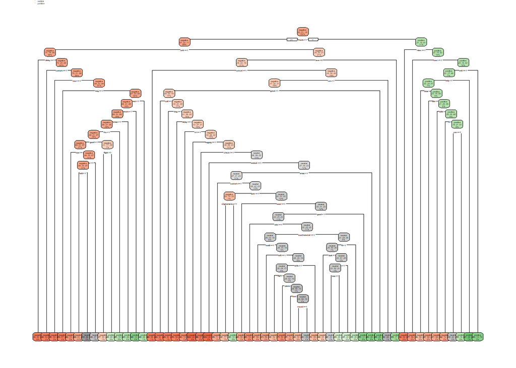

```r
# 시각화
rpart.plot(pruned_dt_model_dtm)
```

[결과]

Classification Tree (DTM) 모델은 Negative 클래스에서 높은 성능을 보였으나, Neutral 클래스에서 성능이 매우 낮다. Positive 클래스에서는 중간 수준의 성능을 보인다.

```r
# Decision Tree 모델 (TF-IDF)
set.seed(123)
dt_model_tfidf <- rpart(airline_sentiment ~ ., data = tfidf_train, method = "class", control = list(cp = 0))

# 가지치기 위한 최적의 cp 값 찾기
printcp(dt_model_tfidf)
```

```
##
## Classification tree:
## rpart(formula = airline_sentiment ~ ., data = tfidf_train, method = "class",
##     control = list(cp = 0))
##
## Variables actually used in tree construction:
##  [1] add           air           airlin        allow         amaz
##  [6] anyth         awesom        bag           best          call
## [11] can           cancel        connect       custom        delay
## [16] email         first         fli           flight        follow
## [21] get           good          got           great         help
## [26] home          hour          just          like          look
## [31] love          luggag        minut         miss          need
## [36] never         new           now           peopl         pilot
## [41] realli        respons       seat          southwestair  start
```

[output cut: 29 more lines]

```r
best_cp_tfidf <- dt_model_tfidf$cptable[which.min(dt_model_tfidf$cptable[,"xerror"]), "CP"]

# Pruning the tree
pruned_dt_model_tfidf <- prune(dt_model_tfidf, cp = best_cp_tfidf)

# 예측
dt_pred_tfidf <- predict(pruned_dt_model_tfidf, newdata = tfidf_validation, type = "class")

# 성능 평가
dt_cm_tfidf <- confusionMatrix(factor(dt_pred_tfidf), factor(tfidf_validation$airline_sentiment))
print(dt_cm_tfidf)
```

```
## Confusion Matrix and Statistics
##
##           Reference
## Prediction negative neutral positive
##   negative      573     146       65
##   neutral        27      49       22
##   positive       26      17       76
##
## Overall Statistics
##
##                Accuracy : 0.6973
##                  95% CI : (0.6678, 0.7256)
##     No Information Rate : 0.6254
##     P-Value [Acc > NIR] : 1.087e-06
##
##                   Kappa : 0.3561
##
##  Mcnemar's Test P-Value : < 2.2e-16
##
## Statistics by Class:
##
##                      Class: negative Class: neutral Class: positive
## Sensitivity                   0.9153        0.23113         0.46626
## Specificity                   0.4373        0.93790         0.94869
## Pos Pred Value                0.7309        0.50000         0.63866
## Neg Pred Value                0.7558        0.81949         0.90136
## Prevalence                    0.6254        0.21179         0.16284
## Detection Rate                0.5724        0.04895         0.07592
## Detection Prevalence          0.7832        0.09790         0.11888
## Balanced Accuracy             0.6763        0.58451         0.70747
```

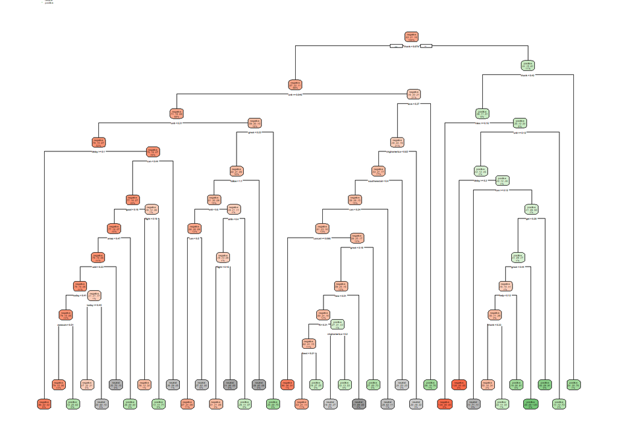

```r
# 시각화
rpart.plot(pruned_dt_model_tfidf)
```

[결과]

종합적으로 보면, Classification Tree (TF-IDF) 모델이 Classification Tree (DTM) 모델보다 전반적으로 더 나은 성능을 보인다. 특히, Accuracy와 Kappa 값을 고려할 때 TF-IDF 기반의 모델이 더 적합한 모델로 보이나 아직까지도 Lasso Regression (TF-IDF) 모델이 가장 좋아보인다.

### Random Forest 모델

```r
# 데이터 프레임의 열 이름 확인 및 수정
colnames(dtm_train) <- make.names(colnames(dtm_train))
colnames(dtm_validation) <- make.names(colnames(dtm_validation))

# 타겟 변수를 팩터로 변환
dtm_train$airline_sentiment <- as.factor(dtm_train$airline_sentiment)
dtm_validation$airline_sentiment <- as.factor(dtm_validation$airline_sentiment)

# Random Forest 모델 (DTM)
set.seed(123)
rf_model_dtm <- randomForest(airline_sentiment ~ ., data = dtm_train, ntree = 500, mtry = sqrt(ncol(dtm_train) - 1))

# 예측
rf_pred_dtm <- predict(rf_model_dtm, newdata = dtm_validation)
rf_pred_dtm <- factor(rf_pred_dtm, levels = levels(dtm_validation$airline_sentiment))

# 성능 평가
rf_cm_dtm <- confusionMatrix(rf_pred_dtm, dtm_validation$airline_sentiment)
print(rf_cm_dtm)
```

```
## Confusion Matrix and Statistics
##
##           Reference
## Prediction negative neutral positive
##   negative      548     121       48
##   neutral        47      73       23
##   positive       31      18       92
##
## Overall Statistics
##
##                Accuracy : 0.7123
##                  95% CI : (0.6831, 0.7402)
##     No Information Rate : 0.6254
##     P-Value [Acc > NIR] : 4.395e-09
##
##                   Kappa : 0.4233
##
##  Mcnemar's Test P-Value : 4.918e-08
##
## Statistics by Class:
##
##                      Class: negative Class: neutral Class: positive
## Sensitivity                   0.8754        0.34434         0.56442
## Specificity                   0.5493        0.91128         0.94153
## Pos Pred Value                0.7643        0.51049         0.65248
## Neg Pred Value                0.7254        0.83800         0.91744
## Prevalence                    0.6254        0.21179         0.16284
## Detection Rate                0.5475        0.07293         0.09191
## Detection Prevalence          0.7163        0.14286         0.14086
## Balanced Accuracy             0.7124        0.62781         0.75297
```

[결과]

Random Forest (DTM) 모델은 Negative 클래스에서 높은 성능을 보였으나, Neutral 클래스에서 성능이 낮다. Positive 클래스에서는 중간 수준의 성능을 보인다.

```r
# Random Forest 모델 (TF-IDF)
colnames(tfidf_train) <- make.names(colnames(tfidf_train))
colnames(tfidf_validation) <- make.names(colnames(tfidf_validation))
tfidf_train$airline_sentiment <- as.factor(tfidf_train$airline_sentiment)
tfidf_validation$airline_sentiment <- as.factor(tfidf_validation$airline_sentiment)
set.seed(123)
rf_model_tfidf <- randomForest(airline_sentiment ~ ., data = tfidf_train, ntree = 500, mtry = sqrt(ncol(tfidf_train) - 1))
rf_pred_tfidf <- predict(rf_model_tfidf, newdata = tfidf_validation)
rf_pred_tfidf <- factor(rf_pred_tfidf, levels = levels(tfidf_validation$airline_sentiment))
rf_cm_tfidf <- confusionMatrix(rf_pred_tfidf, tfidf_validation$airline_sentiment)
print(rf_cm_tfidf)
```

```
## Confusion Matrix and Statistics
##
##           Reference
## Prediction negative neutral positive
##   negative      554     130       54
##   neutral        41      63       21
##   positive       31      19       88
##
## Overall Statistics
##
##                Accuracy : 0.7043
##                  95% CI : (0.675, 0.7324)
##     No Information Rate : 0.6254
##     P-Value [Acc > NIR] : 9.464e-08
##
##                   Kappa : 0.3966
##
##  Mcnemar's Test P-Value : 2.182e-11
##
## Statistics by Class:
##
##                      Class: negative Class: neutral Class: positive
## Sensitivity                   0.8850        0.29717         0.53988
## Specificity                   0.5093        0.92142         0.94033
## Pos Pred Value                0.7507        0.50400         0.63768
## Neg Pred Value                0.7262        0.82991         0.91309
## Prevalence                    0.6254        0.21179         0.16284
## Detection Rate                0.5534        0.06294         0.08791
## Detection Prevalence          0.7373        0.12488         0.13786
## Balanced Accuracy             0.6972        0.60929         0.74011
```

[결과]

### SVM 모델 (RBF 커널)

```r
# SVM 모델 (DTM)
#set.seed(123)
#x_train_dtm <- dtm_train[, -ncol(dtm_train)]
#y_train_dtm <- dtm_train$airline_sentiment
#x_validation_dtm <- dtm_validation[, -ncol(dtm_validation)]
#y_validation_dtm <- dtm_validation$airline_sentiment

# 튜닝 가능한 매개변수 그리드 설정
#tune_grid <- expand.grid(C = 2^(2:6), sigma = 2^(-6:-2))

#train_control <- trainControl(method = "cv", number = 10)

# 모델 학습
#set.seed(123)
#rbf_svm_dtm <- train(
#  x_train_dtm, y_train_dtm,
#  method = "svmRadial",
#  trControl = train_control,
#  tuneGrid = tune_grid,
#  preProcess = c("center", "scale")
#)

# 예측
#rbf_pred_dtm <- predict(rbf_svm_dtm, newdata = x_validation_dtm)
#rbf_pred_dtm <- factor(rbf_pred_dtm, levels = levels(y_validation_dtm))

# 성능 평가 (DTM)
#rbf_cm_dtm <- confusionMatrix(rbf_pred_dtm, y_validation_dtm)
#print(rbf_cm_dtm)
```

[결과]

```r
# SVM 모델 (TF-IDF)
#set.seed(123)
#x_train_tfidf <- tfidf_train[, -ncol(tfidf_train)]
#y_train_tfidf <- tfidf_train$airline_sentiment
#x_validation_tfidf <- tfidf_validation[, -ncol(tfidf_validation)]
#y_validation_tfidf <- tfidf_validation$airline_sentiment

# 상수 피처 제거
#x_train_tfidf <- x_train_tfidf[, sapply(x_train_tfidf, function(x) length(unique(x)) > 1)]
#x_validation_tfidf <- x_validation_tfidf[, colnames(x_train_tfidf)]

# 모델 학습
#set.seed(123)
#rbf_svm_tfidf <- train(
#  x_train_tfidf, y_train_tfidf,
#  method = "svmRadial",
#  trControl = train_control,
#  tuneGrid = tune_grid,
#  preProcess = c("center", "scale")
#)

# 예측
#rbf_pred_tfidf <- predict(rbf_svm_tfidf, newdata = x_validation_tfidf)
#rbf_pred_tfidf <- factor(rbf_pred_tfidf, levels = levels(y_validation_tfidf))

# 성능 평가 (TF-IDF)
#rbf_cm_tfidf <- confusionMatrix(rbf_pred_tfidf, y_validation_tfidf)
#print(rbf_cm_tfidf)
```

[결과]

#### SVM 모델 같은 경우 최초 실행은 성공하였으나 렌더링 무한 대기로 html 제출파일에는 포함하지 않았다.

### Gradient Boosting

```r
library(gbm)
library(smotefamily)

# GBM 모델 하이퍼파라미터 튜닝 (DTM)
set.seed(123)
train_control <- trainControl(method = "cv", number = 5)

tune_grid <- expand.grid(
  n.trees = c(50, 100, 150),
  interaction.depth = c(1, 3, 5),
  shrinkage = c(0.01, 0.1),
  n.minobsinnode = c(10, 20)
)

set.seed(123)
gbm_model_dtm_tuned <- train(
  airline_sentiment ~ ., data = dtm_train,
  method = "gbm",
  trControl = train_control,
  tuneGrid = tune_grid,
  verbose = FALSE
)
# 최적의 모델로 예측
gbm_pred_dtm_tuned <- predict(gbm_model_dtm_tuned, newdata = dtm_validation)

# 성능 평가 (DTM)
gbm_cm_dtm_tuned <- confusionMatrix(gbm_pred_dtm_tuned, dtm_validation$airline_sentiment)
print(gbm_cm_dtm_tuned)
```

```
## Confusion Matrix and Statistics
##
##           Reference
## Prediction negative neutral positive
##   negative      549     136       49
##   neutral        36      53       16
##   positive       41      23       98
##
## Overall Statistics
##
##                Accuracy : 0.6993
##                  95% CI : (0.6698, 0.7276)
##     No Information Rate : 0.6254
##     P-Value [Acc > NIR] : 5.538e-07
##
##                   Kappa : 0.3899
##
##  Mcnemar's Test P-Value : 5.577e-13
##
## Statistics by Class:
##
##                      Class: negative Class: neutral Class: positive
## Sensitivity                   0.8770        0.25000          0.6012
## Specificity                   0.5067        0.93409          0.9236
## Pos Pred Value                0.7480        0.50476          0.6049
## Neg Pred Value                0.7116        0.82254          0.9225
## Prevalence                    0.6254        0.21179          0.1628
## Detection Rate                0.5485        0.05295          0.0979
## Detection Prevalence          0.7333        0.10490          0.1618
## Balanced Accuracy             0.6918        0.59205          0.7624
```

[결과]

Gradient Boosting (DTM) 모델은 Negative 클래스에서 높은 성능을 보였으나, Neutral 클래스에서 성능이 매우 낮다.

```r
# GBM 모델 하이퍼파라미터 튜닝 (TF-IDF)
set.seed(123)
train_control <- trainControl(method = "cv", number = 5)

tune_grid <- expand.grid(
  n.trees = c(50, 100, 150),
  interaction.depth = c(1, 3, 5),
  shrinkage = c(0.01, 0.1),
  n.minobsinnode = c(10, 20)
)

set.seed(123)
gbm_model_tfidf_tuned <- train(
  airline_sentiment ~ ., data = tfidf_train,
  method = "gbm",
  trControl = train_control,
  tuneGrid = tune_grid,
  verbose = FALSE
)
# 최적의 모델로 예측
gbm_pred_tfidf_tuned <- predict(gbm_model_tfidf_tuned, newdata = tfidf_validation)

# 성능 평가 (TF-IDF)
gbm_cm_tfidf_tuned <- confusionMatrix(gbm_pred_tfidf_tuned, tfidf_validation$airline_sentiment)
print(gbm_cm_tfidf_tuned)
```

```
## Confusion Matrix and Statistics
##
##           Reference
## Prediction negative neutral positive
##   negative      557     127       55
##   neutral        40      64       17
##   positive       29      21       91
##
## Overall Statistics
##
##                Accuracy : 0.7113
##                  95% CI : (0.6821, 0.7392)
##     No Information Rate : 0.6254
##     P-Value [Acc > NIR] : 6.557e-09
##
##                   Kappa : 0.4105
##
##  Mcnemar's Test P-Value : 1.243e-11
##
## Statistics by Class:
##
##                      Class: negative Class: neutral Class: positive
## Sensitivity                   0.8898        0.30189         0.55828
## Specificity                   0.5147        0.92776         0.94033
## Pos Pred Value                0.7537        0.52893         0.64539
## Neg Pred Value                0.7366        0.83182         0.91628
## Prevalence                    0.6254        0.21179         0.16284
## Detection Rate                0.5564        0.06394         0.09091
## Detection Prevalence          0.7383        0.12088         0.14086
## Balanced Accuracy             0.7022        0.61482         0.74931
```

[결과]

#### [3.A 종합 결과]

* DTM은 각 문서에서 단어의 등장 횟수를 나타내는 행렬이다. 행렬의 행은 문서, 열은 단어를 나타내며, 각 원소는 해당 문서에서 특정 단어가 등장한 횟수를 나타낸다. * TF-IDF는 단어의 빈도와 문서의 중요도를 함께 고려한 가중치 행렬이다. TF는 단어 빈도를 나타내고, IDF는 단어의 분포를 나타낸다. IDF는 특정 단어가 모든 문서에 공통적으로 등장하면 그 단어의 중요도를 낮추는 역할을 한다.

-> DTM은 단순하고 직관적이며, TF-IDF는 더 정교한 단어 중요도를 반영한다.

이러한 특성에 따라 모델들의 성능이 DTM과 TF-IDF별로 다르게 나온다.

TF-IDF가 더 나은 경우: Logistic Regression, Lasso Regression, Decision Tree, Gradient Boosting 모델에서 TF-IDF가 DTM보다 더 나은 성능을 보인다. 이는 TF-IDF가 중요한 단어에 더 높은 가중치를 부여하여 모델이 더 중요한 특징을 학습할 수 있도록 도와주기 때문이다.

모델과 데이터 특성에 따라 DTM과 TF-IDF의 적합성이 다르다. 선형 모델이나 중요 단어 가중치가 중요한 모델에서는 TF-IDF가 더 유리하며, 비선형 모델이나 거리 기반 모델에서는 DTM이 더 유리할 수 있다. 최적의 모델을 선택할 때는 데이터 특성과 모델 특성을 고려하여 결정해야 한다.

## 3.B

최종적으로 선택한 모델은 무엇이며 test set에 대한 accuracy는 얼마인가?

```r
# 열 이름 표준화
colnames(tfidf_train) <- make.names(colnames(tfidf_train))
colnames(tfidf_validation) <- make.names(colnames(tfidf_validation))
colnames(test_tfidf) <- make.names(colnames(test_tfidf))

# 최적의 모델로 test set에 대한 예측
test_pred_tfidf_tuned <- predict(gbm_model_tfidf_tuned, newdata = test_tfidf)

# 예측 결과를 factor로 변환하여 Confusion Matrix 계산
test_pred_tfidf_tuned <- factor(test_pred_tfidf_tuned, levels = levels(test_tfidf$airline_sentiment))
test_cm_tfidf_tuned <- confusionMatrix(test_pred_tfidf_tuned, test_tfidf$airline_sentiment)

# 성능 평가 결과 출력
print(test_cm_tfidf_tuned)
```

```
## Confusion Matrix and Statistics
##
##           Reference
## Prediction negative neutral positive
##   negative     5101    1093      400
##   neutral       603     739      147
##   positive      344     210     1003
##
## Overall Statistics
##
##                Accuracy : 0.7099
##                  95% CI : (0.7007, 0.7189)
##     No Information Rate : 0.6274
##     P-Value [Acc > NIR] : < 2.2e-16
##
##                   Kappa : 0.4335
##
##  Mcnemar's Test P-Value : < 2.2e-16
##
## Statistics by Class:
##
##                      Class: negative Class: neutral Class: positive
## Sensitivity                   0.8434        0.36190          0.6471
## Specificity                   0.5844        0.90129          0.9315
## Pos Pred Value                0.7736        0.49631          0.6442
## Neg Pred Value                0.6891        0.84014          0.9323
## Prevalence                    0.6274        0.21183          0.1608
## Detection Rate                0.5291        0.07666          0.1040
## Detection Prevalence          0.6840        0.15446          0.1615
## Balanced Accuracy             0.7139        0.63159          0.7893
```

```r
# Accuracy 출력
test_accuracy <- test_cm_tfidf_tuned$overall['Accuracy']
print(paste("Test Set Accuracy:", test_accuracy))
```

```
## [1] "Test Set Accuracy: 0.709854771784232"
```

[결과]

Accuracy: 전체 정확도가 **71%**로, 이는 상당히 좋은 성능을 나타낸다. 대부분의 예측이 정확했다.

Class별 성능: Negative 클래스에서 가장 높은 민감도와 정밀도를 보였으며, 이는 negative 클래스를 잘 예측했음을 의미한다. Neutral 클래스에서 성능이 상대적으로 낮았다. 이는 중립적인 감정을 예측하는 것이 더 어려웠음을 나타낸다. Positive 클래스에서도 적당히 높은 성능을 보인다.

전반적으로 **Gradient Boosting 모델(TF-IDF)**은 좋은 성능을 보인다. 특히 negative 클래스에서 매우 높은 성능을 보이며, 이는 데이터셋에서 가장 큰 비중을 차지하는 클래스이기 때문일 수 있다. neutral 클래스에 대한 성능이 낮은 것은 개선이 가능할 수 있다.

## 3.C

세 class (positive, negative, neutral) 중에서 어떤 class를 분류하기 어려운가?

|  | Negative | Neutral | Positive |
| --- | --- | --- | --- |
| Sensitivity (재현율) | 0.8434 | 0.3619 | 0.6471 |
| Specificity | 0.5844 | 0.9013 | 0.9315 |
| Pos Pred Value (정밀도) | 0.7736 | 0.4963 | 0.6442 |
| Neg Pred Value | 0.6891 | 0.8401 | 0.9323 |

- Negative : Sensitivity와 Precision 모두 높은 편으로 해당 클래스를 잘 예측하고 있다.
- Neutral : Sensitivity, Pos Pred Value 모두 낮아 예측에 어려움이 있다.
- Positive : Sensitivity와 Precision 모두 중간으로 안정적인 예측을 한다.

  모델의 confusion maatrix 출력 과정에서 우려했던 것처럼 Neutral의 예측이 가장 어려웠다.

  **Neutral**에 대한 예측 성능을 개선하기 위해 추가적인 피처 엔지니어링, 데이터 불균형 처리, 또는 모델링 기법을 개선할 필요가 있다. 리서치 결과, 데이터셋 자체의 클래스 불균형이 있기 때문에 이를 완화하기 위해 더 복잡한 모델을 사용해야 한다고 한다. SMOTE와 오버샘플링 등의 기법도 있다고 한다.